# Hausaufgabe4 Teil 1

Vorbereitung für die Hausaufgabe

```r
library(tidyverse)
library(e1071)
library(caret)
library(pROC)
titanic <- read_delim("titanic.csv", ";",
    escape_double = FALSE, trim_ws = TRUE)
```

Notiz: Ich habe mich dazu entschieden drei verschiedene Notebooks für diese Hausaufgabe anzulegen, da ich Unterschiede bei den verschiedenen Features aufzeigen wollte. Leider lies sich dies nicht in einem Notebook vereinen, weil Schwierigkeiten mit dem Umschreiben des Codes hatte, wenn ich die Algrotihmen mehrmals in einem Notebook verwendete. Daher hier der Teil 1 mit den hinzugefügten Features fare und parch. Am Ende des letzten Teils des letzten Notebooks werde ich versuchen eine größe Erklärung für die Unterschiede in der Performance zu finden. Die simplen Unterschiede sind jeweils kurz unter den Modellen vermerkt.

```r
titanic_svm <- titanic %>%
  select(survived,pclass,age,sex,fare,parch) %>%
  mutate(age = as.numeric(str_replace(age,",","."))) %>%
  mutate(fare = as.numeric(str_replace(fare,",","."))) %>%
  mutate(survived = as.factor(survived)) %>%
  mutate(sex = ifelse(sex == "female", 1, 0))
```

```r
#titanic %>%
  #mutate(embarked =replace(embarked, which(embarked =="C"), 0))  %>%
  #mutate(embarked =replace(embarked, which(embarked =="Q"), 1))  %>%
  #mutate(embarked =replace(embarked, which(embarked =="S"), 2))
```

```r
titanic_svm <- na.omit(titanic_svm)
titanic_svm <- titanic_svm
```

```r
train_control <- trainControl(method="cv", number=10, , savePredictions = TRUE)
```

```r
set.seed(393)
inTrain <- createDataPartition(
  y = titanic_svm$survived,
  p = .8,
  list = FALSE)
training <- titanic_svm[ inTrain,]
testing  <- titanic_svm[-inTrain,]
```

```r
model.svm <- train(survived~., data=training, trControl=train_control, method="svmLinear")
summary(model.svm)
```

```
## Length  Class   Mode
##      1   ksvm     S4
```

```r
pred <- predict(model.svm, testing[,-1], probability = FALSE)
```

```r
model.svm$pred
```

| pred | obs | rowIndex | C | Resample |
| --- | --- | --- | --- | --- |
| 1 | 1 | 11 | 1 | Fold01 |
| 0 | 1 | 47 | 1 | Fold01 |
| 1 | 1 | 50 | 1 | Fold01 |
| 1 | 1 | 54 | 1 | Fold01 |
| 0 | 0 | 59 | 1 | Fold01 |
| 0 | 0 | 60 | 1 | Fold01 |
| 1 | 1 | 72 | 1 | Fold01 |
| 1 | 1 | 77 | 1 | Fold01 |
| 0 | 1 | 88 | 1 | Fold01 |
| 0 | 1 | 90 | 1 | Fold01 |

[output cut: 827 more lines]

```r
(test.results <- cbind(pred, testing))
```

| pred | survived | pclass | age | sex | fare | parch |
| --- | --- | --- | --- | --- | --- | --- |
| 0 | 1 | 1 | 0.9167 | 0 | 151.5500 | 2 |
| 1 | 1 | 1 | 18.0000 | 1 | 227.5250 | 0 |
| 1 | 1 | 1 | 24.0000 | 1 | 69.3000 | 0 |
| 0 | 0 | 1 | 24.0000 | 0 | 247.5208 | 1 |
| 0 | 0 | 1 | 25.0000 | 0 | 26.0000 | 0 |
| 0 | 0 | 1 | 42.0000 | 0 | 26.5500 | 0 |
| 1 | 1 | 1 | 59.0000 | 1 | 51.4792 | 0 |
| 1 | 1 | 1 | 60.0000 | 1 | 76.2917 | 0 |
| 0 | 0 | 1 | 45.0000 | 0 | 26.5500 | 0 |
| 1 | 1 | 1 | 58.0000 | 1 | 512.3292 | 1 |

[output cut: 198 more lines]

```r
test.results <- test.results %>%
  mutate(survived = as.numeric(survived)) %>%
  mutate(pred = as.numeric(pred))
```

```r
head(attr(pred, "probabilities"))
```

```r
table(test.results$pred, testing$survived)
```

```
##
##       0   1
##   1 110  22
##   2  13  63
```

```r
confusionMatrix(pred,testing$survived)
```

```
## Confusion Matrix and Statistics
##
##           Reference
## Prediction   0   1
##          0 110  22
##          1  13  63
##
##                Accuracy : 0.8317
##                  95% CI : (0.7738, 0.8799)
##     No Information Rate : 0.5913
##     P-Value [Acc > NIR] : 7.477e-14
##
##                   Kappa : 0.6461
##
##  Mcnemar's Test P-Value : 0.1763
##
##             Sensitivity : 0.8943
##             Specificity : 0.7412
##          Pos Pred Value : 0.8333
##          Neg Pred Value : 0.8289
##              Prevalence : 0.5913
##          Detection Rate : 0.5288
##    Detection Prevalence : 0.6346
##       Balanced Accuracy : 0.8177
##
##        'Positive' Class : 0
##
```

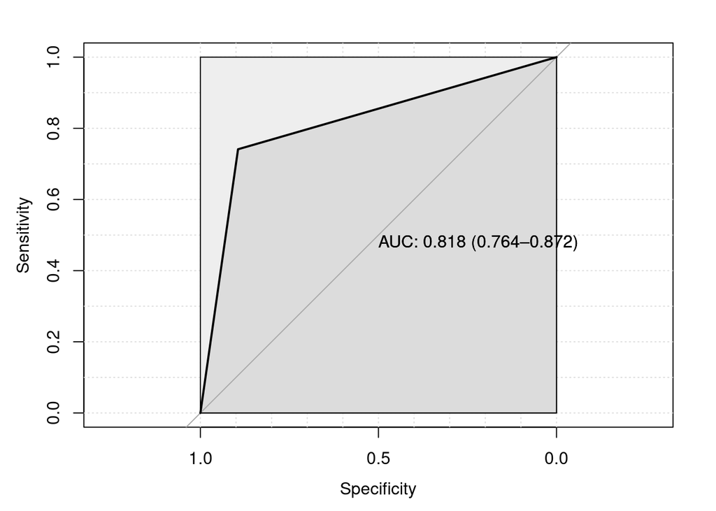

```r
pROC_obj <- roc(test.results$survived, test.results$pred,
            smoothed = TRUE,
            ci=TRUE, ci.alpha=0.9, stratified=FALSE,
            plot=TRUE, auc.polygon=TRUE, max.auc.polygon=TRUE, grid=TRUE,
            print.auc=TRUE, show.thres=TRUE)
```

Bei SVM ändert sich nichts an dem Wert, wenn man fare und parch hinzufügt. Scheint so als hätten sie keinen Einfluss.

```r
saveRDS(model.svm, "./titanic.svm.rds")
```

Naive Bayes

```r
my_training <- training %>%
  mutate(survived = as.factor(survived))%>%
  mutate(sex = as.factor(sex))%>%
  mutate(pclass = as.factor(pclass)) %>%
  mutate(fare = as.factor(fare)) %>%
  mutate(parch = as.factor(parch)) %>%
mutate(age = as.factor(ifelse(age < 14, "child", "adult")))
model <- naiveBayes(survived ~ ., data = my_training)
model
```

```
##
## Naive Bayes Classifier for Discrete Predictors
##
## Call:
## naiveBayes.default(x = X, y = Y, laplace = laplace)
##
## A-priori probabilities:
## Y
##         0         1
## 0.5913978 0.4086022
##
## Conditional probabilities:
##    pclass
## Y           1         2         3
##   0 0.1474747 0.2363636 0.6161616
##   1 0.4444444 0.2368421 0.3187135
##
##    age
## Y        adult      child
##   0 0.92323232 0.07676768
##   1 0.88011696 0.11988304
##
##    sex
## Y           0         1
##   0 0.8323232 0.1676768
##   1 0.3304094 0.6695906
##
##    fare
## Y             0      3.1708      4.0125      6.2375      6.4375        6.45
##   0 0.010101010 0.000000000 0.002020202 0.002020202 0.002020202 0.002020202
##   1 0.005847953 0.002923977 0.000000000 0.000000000 0.000000000 0.000000000
##    fare
## Y        6.4958        6.75        6.95       6.975           7      7.0458
##   0 0.006060606 0.002020202 0.000000000 0.002020202 0.000000000 0.002020202
##   1 0.000000000 0.000000000 0.002923977 0.002923977 0.002923977 0.000000000
##    fare
## Y          7.05      7.0542       7.125      7.1417       7.225      7.2292
##   0 0.012121212 0.004040404 0.006060606 0.000000000 0.016161616 0.016161616
##   1 0.000000000 0.000000000 0.000000000 0.002923977 0.011695906 0.014619883
##    fare
```

[output cut: 137 more lines]

```
##   0 0.006060606 0.000000000 0.002020202 0.000000000 0.002020202 0.004040404
##   1 0.005847953 0.005847953 0.008771930 0.008771930 0.005847953 0.002923977
##    fare
## Y       227.525    247.5208     262.375         263    512.3292
##   0 0.002020202 0.000000000 0.002020202 0.004040404 0.000000000
##   1 0.005847953 0.005847953 0.017543860 0.011695906 0.008771930
##
##    parch
## Y             0           1           2           3           4           5
##   0 0.791919192 0.107070707 0.074747475 0.006060606 0.008080808 0.008080808
##   1 0.643274854 0.225146199 0.111111111 0.014619883 0.002923977 0.002923977
##    parch
## Y             6
##   0 0.004040404
##   1 0.000000000
```

```r
my_testing <- testing %>%
  mutate(sex = as.factor(sex)) %>%
  mutate(pclass = as.factor(pclass))%>%
  mutate(fare = as.factor(fare)) %>%
  mutate(parch = as.factor(parch)) %>%
  mutate(age = as.factor(ifelse(age < 7, "child", "adult")))
pred <- predict(model, my_testing)
table(pred, my_testing$survived)
```

```
##
## pred   0   1
##    0 102  28
##    1  21  57
```

```r
(test.results <- cbind(pred, my_testing))
```

| pred | survived | pclass | age | sex | fare | parch |
| --- | --- | --- | --- | --- | --- | --- |
| 1 | 1 | 1 | child | 0 | 151.55 | 2 |
| 1 | 1 | 1 | adult | 1 | 227.525 | 0 |
| 1 | 1 | 1 | adult | 1 | 69.3 | 0 |
| 1 | 0 | 1 | adult | 0 | 247.5208 | 1 |
| 0 | 0 | 1 | adult | 0 | 26 | 0 |
| 1 | 0 | 1 | adult | 0 | 26.55 | 0 |
| 1 | 1 | 1 | adult | 1 | 51.4792 | 0 |
| 1 | 1 | 1 | adult | 1 | 76.2917 | 0 |
| 1 | 0 | 1 | adult | 0 | 26.55 | 0 |
| 1 | 1 | 1 | adult | 1 | 512.3292 | 1 |

[output cut: 198 more lines]

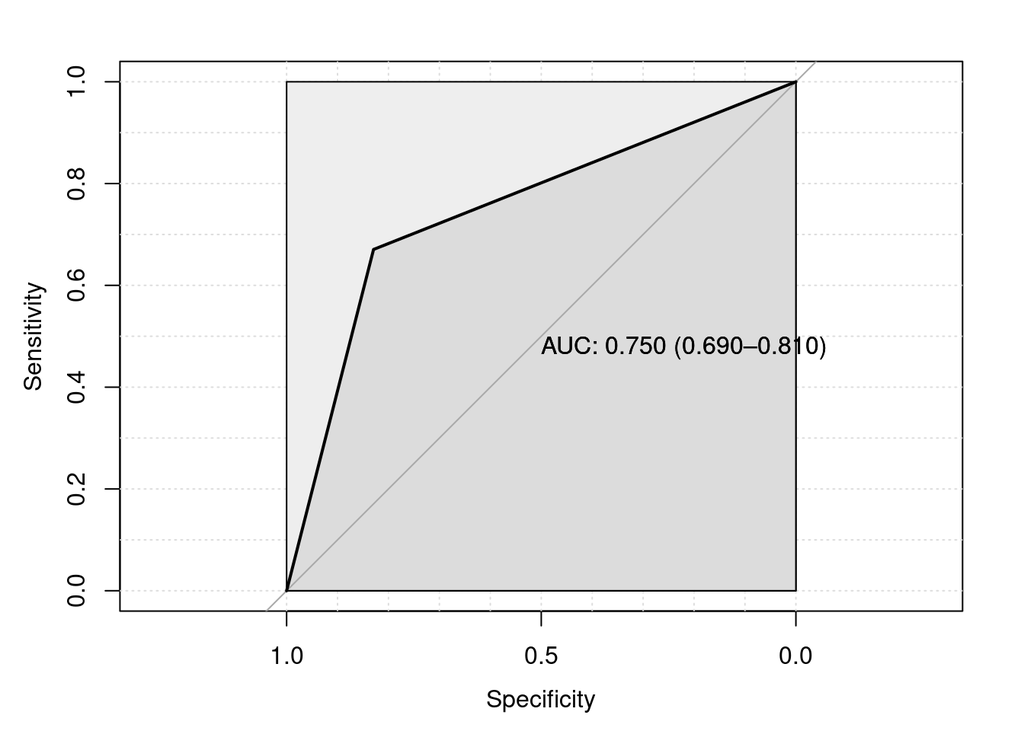

```r
test.results <- test.results %>%
  mutate(pred = as.numeric(pred))
pROC_obj <- roc(as.numeric(as.factor(test.results$survived)), test.results$pred,
            smoothed = TRUE,
            ci=TRUE, ci.alpha=0.9, stratified=FALSE,
            plot=TRUE, auc.polygon=TRUE, max.auc.polygon=TRUE, grid=TRUE,
            print.auc=TRUE, show.thres=TRUE)
```

Bei Naive Bates verschlechtert sich der AUC beim Hinzufügen von fare und parch schon recht deutlich. Vermutlich sind die Features nicht ausschlaggebend für das Überleben der Passagiere. Durch das mehrmalige Ausführen der Features bei Naive Bates scheint der AUC somit zu sinken.

Decision Tree

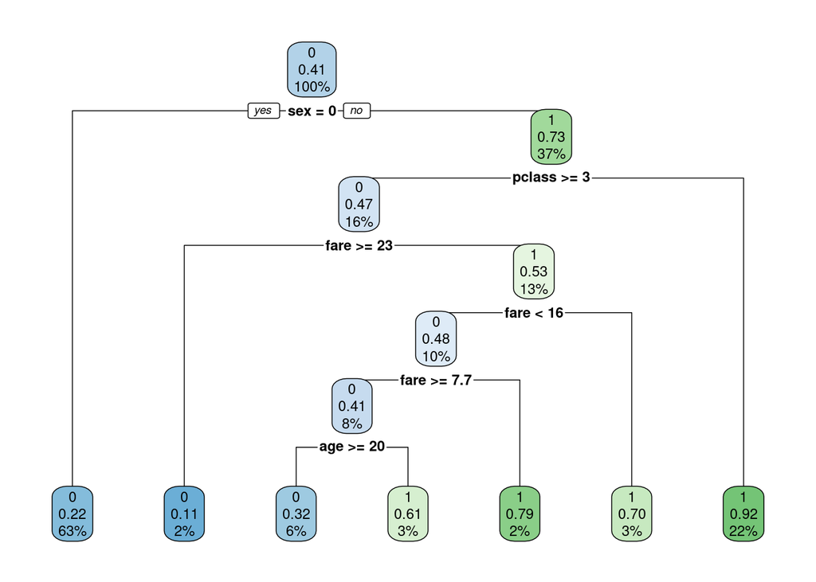

```r
library(rpart)
library(rpart.plot)
tree<- rpart(survived~., data = training, method = 'class')
rpart.plot(tree)
```

```r
dt_results <- predict(tree, testing[,-1], type = 'prob')
head(model.results.dt <- cbind(testing,dt_results),500)
```

|  | survived | pclass | age | sex | fare | parch | 0 | 1 |
| --- | --- | --- | --- | --- | --- | --- | --- | --- |
| 1 | 1 | 1 | 0.9167 | 0 | 151.5500 | 2 | 0.78476190 | 0.2152381 |
| 2 | 1 | 1 | 18.0000 | 1 | 227.5250 | 0 | 0.07692308 | 0.9230769 |
| 3 | 1 | 1 | 24.0000 | 1 | 69.3000 | 0 | 0.07692308 | 0.9230769 |
| 4 | 0 | 1 | 24.0000 | 0 | 247.5208 | 1 | 0.78476190 | 0.2152381 |
| 5 | 0 | 1 | 25.0000 | 0 | 26.0000 | 0 | 0.78476190 | 0.2152381 |
| 6 | 0 | 1 | 42.0000 | 0 | 26.5500 | 0 | 0.78476190 | 0.2152381 |
| 7 | 1 | 1 | 59.0000 | 1 | 51.4792 | 0 | 0.07692308 | 0.9230769 |
| 8 | 1 | 1 | 60.0000 | 1 | 76.2917 | 0 | 0.07692308 | 0.9230769 |
| 9 | 0 | 1 | 45.0000 | 0 | 26.5500 | 0 | 0.78476190 | 0.2152381 |
| 10 | 1 | 1 | 58.0000 | 1 | 512.3292 | 1 | 0.07692308 | 0.9230769 |

[output cut: 198 more lines]

```r
test.results2 <- test.results %>%
  mutate(pred = ifelse(pred>=0.5,1,0))
table(test.results2$pred, testing$survived)
```

```
##
##       0   1
##   1 123  85
```

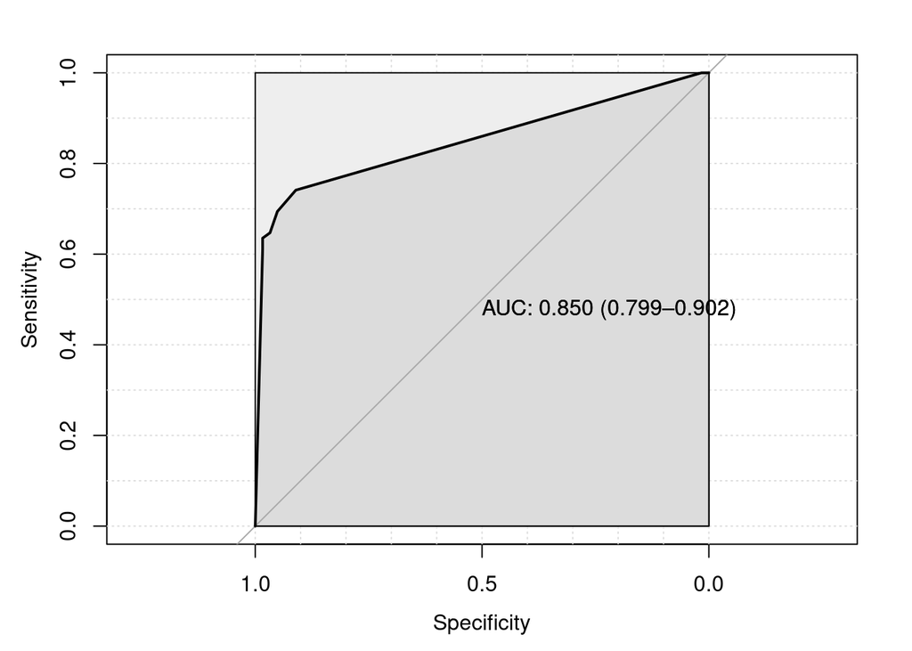

```r
pROC_obj <- roc(model.results.dt$survived,model.results.dt$`1`,
            smoothed = TRUE,
            # arguments for ci
            ci=TRUE, ci.alpha=0.9, stratified=FALSE,
            # arguments for plot
            plot=TRUE, auc.polygon=TRUE, max.auc.polygon=TRUE, grid=TRUE,
            print.auc=TRUE, show.thres=TRUE)
```